# BANES Traffic - Transits

# Introduction

This project explores data made available by [BathHacked and BANES Council](https://www.bathhacked.org) about traffic around Bath. The data are from automatic number plate readers (ANPRs). BathHacked have used the data to explore vehicle emissions in and around the city.

My initial interest is the traffic entering the city along the Warminster Road. This notebook looks at traffic transiting Bath (ie seen entering and leaving), with a particular highlight on the Warminster Road.

```r
library(dplyr)
library(tidyr)
library(ggplot2)
library(readxl)
library(lubridate)
library(circlize)
library(purrr)
library(networkD3)
library(htmlwidgets)
library(htmltools)
source("BHTransits_f.R")
```

# Initial Data

I’ve plotted the locations of the data using a Tableau workbook.

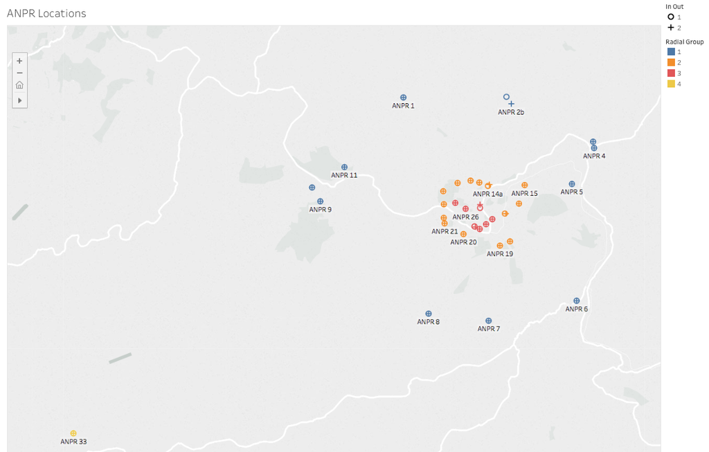

ANPR Locations

The ANPRs consist of one in the far south-west (radial 4), an outer circle (radial 1) and inner circle (radial 2) and ANPRs near car parks (radial 3). Because of the focus on transiting traffic, I’m most interested in radial 1. I will group these into 5 clusters, as shown on the map: North (by-pass at Swainswick heading to and from the M4), Lansdown; East (Box Road to Chippenham, and Bathford); South (Brassnocker Hill, and 2 others); and West, towards Bristol.

# Transits only

We focus on those vehicles that are identified, and which transit the city in the sense of being observed to pass in through radial 1 and then out again within a time limit.

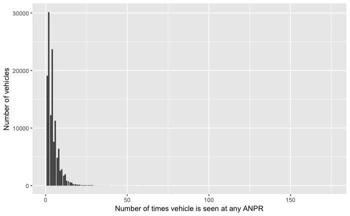

```r
#track carefully what data we are able to use
n_full <- nrow(obs) #number of observations
obsv <- obs %>% filter(vehicle_id != "")
n_vid <- nrow(obsv) #observations with a vehicle ID
vid_n <- obsv %>%
  count(vehicle_id)
#plot the number of observations per vehicle
ggplot(vid_n, aes(x = n)) + geom_bar() +
  xlab("Number of times vehicle is seen at any ANPR") +
  ylab("Number of vehicles")
```

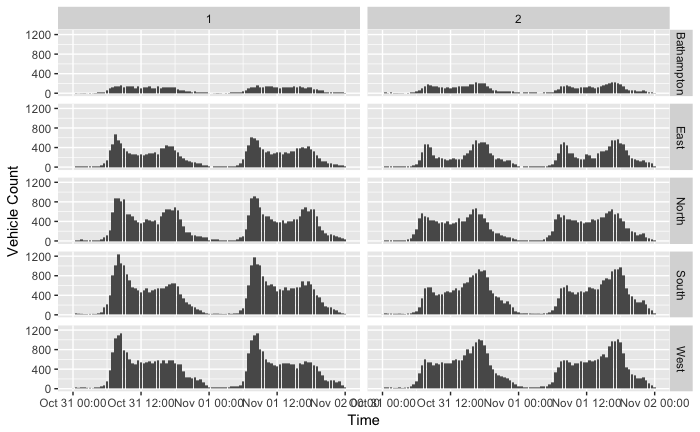

```r
#observations at radial 1 per vehicle
obs1 <- obsv %>%
  filter(site_id %in% r1$id)
vid1_n <- obs1 %>% count(vehicle_id) #number of observations on radial 1
vid1_2P <- vid1_n %>% filter(n >= 2) #filtered to 2 or more
#limit analysis to at least two crossings of radial 1
obs1 <- obs1 %>% filter(vehicle_id %in% vid1_2P$vehicle_id) %>%
  #now with this smaller set
  #create a time bin
  mutate(tbin = lubridate::round_date(time, "30 mins")) %>%
  #add in the groupings
  left_join(r1 %>% select(id, description, in_out, group1),
            by = c("site_id"="id"))
#not the most interesting of plots, because of the condition that it involves at least 2 rad1 crossings
ggplot(obs1, aes(x=tbin)) + geom_bar() +
  facet_grid(group1 ~ in_out) +
  labs(x = "Time", y="Vehicle Count")
```

The graph shows that in our sample of 609287 ANPR observations, we have 581580 with a vehicle ID, so that we can track. Of these vehicles, 19128 are only seen once, so there is no chance of a transit. Looking only at those crossing radial 1, we have 100040 distinct vehicles crossing this radial, of which 81416 cross radial 1 more than once so could be transits.

We look through the ins and outs for each vehicle, and label the individual transits: over several days vehicles may make a few - some vehicles make more than 10 per day (buses?). We filter down to valid transits, a pair starting with and in and ending with an out, and lasting less than a certain number of minutes.

```r
# test_veh <- obs1 %>%
#   sample_n(10000) %>% #first downsample
#   select(vehicle_id) %>%
#   distinct %>%
#   sample_n(1000) #main downsample
obs1t <- obs1 %>%
  # filter(time < as.POSIXct("2017-11-01 00:00:00.0")) %>%  #sample: 31/10/17
  #test sample
  # filter(vehicle_id %in% test_veh$vehicle_id) %>%
  #for each vehicle in turn
  group_by(vehicle_id) %>%
  arrange(time) %>%
  mutate(transitID = getTransitIDs(in_out)) %>%
  #tidy the transit IDs
  drop_na() %>% #where first for the vehicle is a 2
  slice(1:2) #just the first 2 in any transit, to ignore extra 2s
#check for vehicle transits with entry, not exit
#or with time of transit too long
eneBase <- obs1t %>%
  group_by(vehicle_id, transitID) %>%
  select(vehicle_id, transitID, time) %>%
  mutate(n = n(),
         ttime = (last(time) - first(time))/60) %>%
  select(-time) %>%
  distinct()
```

## Basic chord chart

Using these valid transits, we generate some chord plots using `circlize`.

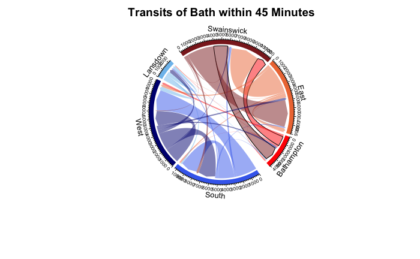

```r
# layout(matrix(1:2, 1, 2))
z <- trChord(obs1t, eneBase, 45)
title("Transits of Bath within 45 Minutes")
```

```r
# (z <- trChord(obs1t, eneBase, 60))
# title("Transits of Bath within 60 Minutes")
```

Next would be to do a split of these transits by vehicle type, or to look at peak hours, but that will come in a later section.

## Bathampton Traffic

To put the transit traffic of 1,500-2,000 per day in context, we look in more detail at the overall traffic passing through Bathampton at Dry Arch. We see about 5% of vehicles are not identified. Probably a larger proportion are missed or unidentified at some ANPR as they pass through Bath, though the probability is unlikely to be 5% independently at each, since location, cleanliness of number plate, or being a foreign vehicle will be shared reasons for not being recognised.

```r
# Bathampton totals
bht <- obs %>%
  # time sample
  filter(time < as.POSIXct("2017-11-01 00:00:00.0")) %>%
  # just Bathampton observations
  filter(site_id %in% c(9, 10)) %>%
  mutate(vehicle_id = if_else(vehicle_id=="", NA_character_, vehicle_id))
summary(bht)
```

```
    site_id        vehicle_id             time
 Min.   : 9.000   Length:8691        Min.   :2017-10-31 00:10:54
 1st Qu.: 9.000   Class :character   1st Qu.:2017-10-31 09:31:35
 Median : 9.000   Mode  :character   Median :2017-10-31 13:25:29
 Mean   : 9.448                      Mean   :2017-10-31 13:13:39
 3rd Qu.:10.000                      3rd Qu.:2017-10-31 16:46:35
 Max.   :10.000                      Max.   :2017-10-31 22:59:59
```

```r
bht %>% filter(is.na(vehicle_id)) %>% summarise(n())
```

| n() |
| --- |
| 455 |

For the vehicles that are identified by the ANPR, we can track them. We get the sequence of observations per vehicle, and start a new one each time we see ‘10’ (heading into Bath at Dry Arch) and end one after each ‘9’ (leaving Bath at Dry Arch).

```r
 # Bathhampton if it contains either 9 or 10
isBH <- function(x){(9 %in% x)||(10 %in% x)}
#use these to log in and out
in1 <- anpr %>%
  filter((radial_group == 1) & (in_out == 1)) %>%
  select(id)
out1 <- anpr %>%
  filter((radial_group == 1) & (in_out == 2)) %>%
  select(id)
# test with a few vehicles
test_veh <- obs %>%
  # sample_n(10000) %>% #first downsample
  select(vehicle_id) %>%
  distinct
# %>%
#   sample_n(100000) #main downsample
aseq <- obs %>%
  # vehicle test sample
  filter(vehicle_id %in% test_veh$vehicle_id) %>%
  # time sample
  # filter(time < as.POSIXct("2017-11-01 00:00:00.0")) %>%
  # test each vehicle for bathampton
  # only code the visits those that at some point pass through BH
  group_by(vehicle_id) %>%
  mutate(DA = isBH(site_id)) %>%
  filter(DA == TRUE) %>%
  # add visit id
  mutate(visit = getVisitIDs(site_id)) %>%
  select(-DA) %>%
  # now check for each visit
  #and further filter to vehicles and visits through BH
  group_by(visit, add = T) %>%
  mutate(DA = isBH(site_id)) %>%
  filter(DA == TRUE) %>%
  select(-DA) %>%
  #add time from start of visit
  mutate( visit_time = (time - min(time))/60)
```

Originally tried out a forcenetwork from `networkD3` for this, but really we want more control over the position of x and y, so stick to ggplot. This is clear in a geographical way, but the arrows overlap a lot.

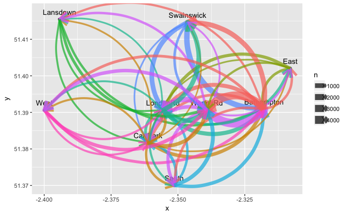

```r
# adapt the ANPR location data
fnode_detail <- anpr %>%
  mutate(loc =
           case_when(
             id %in% 1:2 ~ "Lansdown",
             id %in% 3:4 ~ "Swainswick",
             id %in% 5:8 ~ "East",
             id %in% 9:10 ~ "Bathampton",
             id %in% 11:16 ~ "South",
             id %in% 17:22 ~ "West",
             id %in% 27:28 ~ "LondonRd",
             id %in% 29:30 ~ "Warm'rRd",
             id %in% 51:65 ~ "Car Park",
             TRUE ~ "Other")) %>%
  filter(loc != "Other") %>%
  # some locations - with override, to get a more compact plot, later
  group_by(loc) %>%
  mutate(x = if_else(loc == "West", -2.4, mean(longitude)),
         y = if_else(loc =="South", 51.37, mean(latitude)))
#for plotting
fnode <- fnode_detail %>%
  mutate(group = coalesce(group1, if_else(radial_group==2, "MidRing", "Car Park"))) %>%
  select(loc, x, y, group) %>%
  distinct()
fseq <- aseq %>%
  inner_join(fnode_detail %>% select(id, loc, x, y),
             by = c("site_id"="id")) %>%
  group_by(vehicle_id, visit) %>%
  arrange(time) %>%
  # get pairs
  mutate(prev_loc = lag(loc),
         prev_x = lag(x),
         prev_y = lag(y),
         link_time = (time - lag(time))/60) %>%
  na.omit()
#get frequencies for link strength
flink <- fseq %>%
  ungroup() %>%
  select(-site_id, -vehicle_id, -time, -visit) %>%
  group_by(loc, x, y, prev_loc, prev_x, prev_y) %>%
  summarise(mean_time = mean(link_time),
            n = n())

#combined plot of these
ggplot(fnode,
       aes(x = x, y = y, label=loc)) +
  geom_point() +
  geom_text(nudge_y = 0.002) +
  geom_curve(data = flink %>% filter(loc != prev_loc),
             aes(x = prev_x, y = prev_y,
                 xend = x, yend = y,
                 size = n,
                 colour = prev_loc),
                alpha = 0.7,
                 arrow = arrow(length = unit(0.05, "npc"))) +
  scale_colour_hue(guide = 'none')
```

Perhaps a Sankey diagram would be more effective? However, the ordering of the nodes is tricky. We could have ‘entry’ on the left and ‘exit’ on the right, but that potentially means needing links from London Road to Warminster Road, and vice versa. So we need to separate the two directions at each ANPR. And hope that there are no ‘oddities’ which remain difficult to encode. So start with a very simplified set of sequences: Bathampton, Swainswick with and without London Road.

We highlight those vehicles travelling direct between Swainswick and Bathampton (Dry Arch) in a paler colour. Including the Warminster Rd ANPR (by Sydney Gardens) means we catch a few cars that aren’t noticed by the London Rd ANPR. This emphasises that the counts of ‘direct’ travel is an upper estimate. Adding in the ‘car park’ ANPRs didn’t reduce the count of directs any further (on this sample of visits), but it makes the Sankey diagram a lot more complex, so leave it out.

```r
#plot Sankey
trSankey(sseq %>% filter(BSDirect != "Not A36-A46"),
         snode)
```

```
Links is a tbl_df. Converting to a plain data frame.
```

[interactive chart not shown]

The little connections are distracting. So remove links with less than 0.5% of the total count. This is a lot cleaner. It also clarifies that we are not showing every visit here, because we are omitting those that leave by other routes. A quick what-if? including exits and entries to South and West shows what we saw in the chord chart, that these are not a big source of traffic. Probably a bigger part of the remainder are those that go in and park and are not seen again (within the time sample taken).

```r
trSankey(sseq %>% filter(BSDirect != "Not A36-A46"),
         snode,
         minPct = 0.5,
         fontSize = 20)
```

```
Links is a tbl_df. Converting to a plain data frame.
```

[interactive chart not shown]

Are we missing some cross-bridge traffic that are still transits? What if drivers coming from the South or West avoid London Road by going up Warminster Road then through Bathampton and over the toll bridge?

Temporarily, I reinstated the South and West traffic, but found only 8 transits (out of 24,000) recorded at Swainswick heading South and then next at Warminster Rd heading West, and only 2 in the other direction. So a very small fraction paying to avoid London Road.

# Types of Vehicle

This Sankey diagram shows the overall traffic patterns, still for transits of Bath, that I’m most interested in. There will be other flows across the toll bridge, such as locals from Bathampton or Batheaston who then aren’t recorded by the ANPRs. Not much I can do about that for the moment.

The questions I’d like to tackle are when the vehicles travel, and what sort they are. Here we focus on the type of vehicle. I think the coding is ‘TAXIS’, ‘SPVs’ special purpose vehicles, “PSVs” public service vehicles, “LCVs” light commercial vehicles, “HCVs” heavy commercial vehicles, “2/3 Wheelers”, and blank.

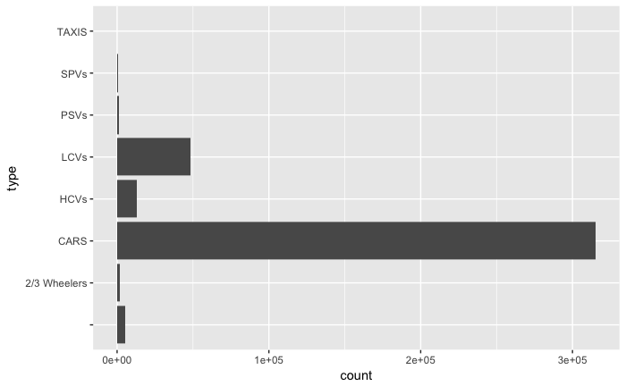

```r
veh <- read.csv("Data/banes_anpr_data/vehicles.csv", stringsAsFactors = F)
ggplot(veh, aes(type)) + geom_bar() +
  coord_flip()
```

```r
obs1t_v <- obs1t %>%
  left_join(veh %>% select(id, type) %>% distinct(),
            by= c("vehicle_id" = "id"))
```

## Chord charts by vehicle type

So now we can do a variety of chord charts. Indeed, we can do one that shows all 3 main types together, as different colours.

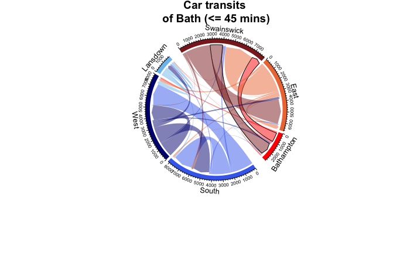

```r
min_t <- 45
z <- trChord(obs1t_v %>% filter(type=="CARS") ,
              eneBase, min_t)
title(paste0("Car transits \nof Bath (<= ",min_t," mins)"))
```

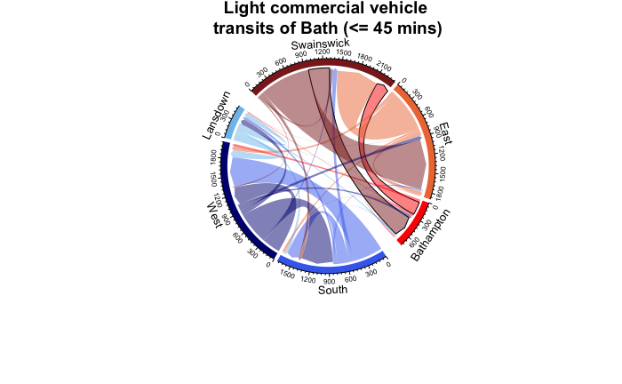

```r
z <- trChord(obs1t_v %>% filter(type=="LCVs") ,
              eneBase, min_t)
title(paste0("Light commercial vehicle \ntransits of Bath (<= ",min_t," mins)"))
```

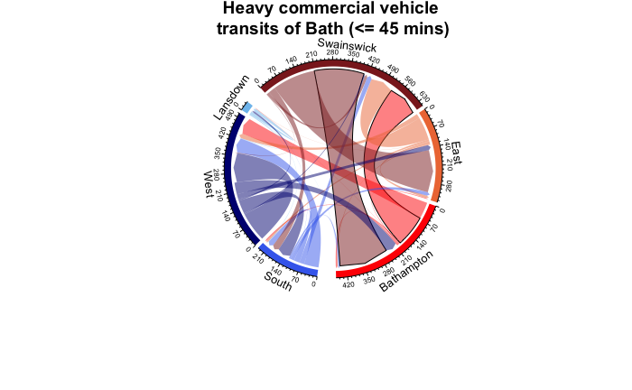

```r
z <- trChord(obs1t_v %>% filter(type=="HCVs") ,
              eneBase, min_t)
title(paste0("Heavy commercial vehicle \ntransits of Bath (<= ",min_t," mins)"))
```

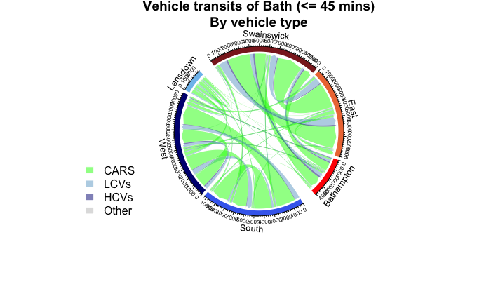

```r
z <- trChord(obs1t_v, eneBase, min_t, by_type=T, invisible_type = c())
title(paste0("Vehicle transits of Bath (<= ",min_t," mins)\nBy vehicle type"))
```

```r
#some stats
z <- z %>%
  #go bidirectional
  mutate(route = paste(min(entry, exit), max(entry,exit), sep="<>"))
#calculate some statistics
addmargins(xtabs(n ~ route + type, data = z))
```

```
                        type
route                          2/3 Wheelers  CARS  HCVs  LCVs  PSVs  SPVs   Sum
  Bathampton<>Bathampton     2            0    96     6    17     4     0   125
  Bathampton<>East           2            0    69     6    13     0     0    90
  Bathampton<>Lansdown       2            0    89     2    41     0     0   134
  Bathampton<>South          3            0    85    12    20     2     0   122
  Bathampton<>Swainswick    51            0  2063   318   568     3     0  3003
  Bathampton<>West          13            0   289   111    86     3     0   502
  East<>East                 2            0   389    10    75     5     0   481
  East<>Lansdown             2            0    70     1    17     0     0    90
  East<>South                6            0   207    21    54     5     0   293
  East<>Swainswick          85            0  5154   258  1534    14     0  7045
  East<>West                 5            0   421    38   124     9     1   598
  Lansdown<>Lansdown         5            0   276    11    83     5     0   380
  Lansdown<>South            6            0   254     3    88     0     0   351
  Lansdown<>Swainswick       1            0    39     0     8     0     0    48
  Lansdown<>West            15            0   739     8   211     1     0   974
  South<>South              16            0  1825    22   196    21     0  2080
  South<>Swainswick         12            0   391    46   137     0     0   586
  South<>West               46            1  3575   109  1017    13     0  4761
  Swainswick<>Swainswick     3            0    78    11    38     0     0   130
  Swainswick<>West           4            0   115     7    36     4     0   166
  West<>West                14            1  1436   116   288    24     3  1882
  Sum                      295            2 17660  1116  4651   113     4 23841
```

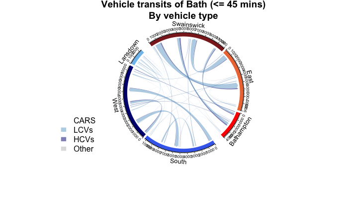

```r
#hiding cars
z <- trChord(obs1t_v, eneBase, min_t, by_type=T, invisible_type = c("CARS"),
             colours = c("white", "skyblue3", "navyblue", "grey"))
title(paste0("Vehicle transits of Bath (<= ",min_t," mins)\nBy vehicle type"))
```

# Sankey charts by vehicle type

Now we can return to the Sankey charts to see how the 3 different types of vehicle route, on their transit through Bath. The ‘title’ doesn’t show up in notebook here, but does in the html, so that’s ok!

```r
trSankey(sseq_t %>% filter(BSDirect != "Not A36-A46"), snode,
         # minPct = 0.5,
         fontSize = 20, title = "All vehicle types - routes on A36-A46 transits only..")
```

```
Links is a tbl_df. Converting to a plain data frame.
```

### All vehicle types - routes on A36-A46 transits only..

[interactive chart not shown]

After the surprise that around half of vehicles were already using the toll bridge, when split by vehicle type the results are less suprising: * heavy commercial vehicles nearly all go via London Road (200/213 in one direction, for example, over 2 days) * light commercial vehicles going South-North are split 50:50, but going North-South the majority (311/530 = 59%) come over the toll bridge (or at least are not recorded at the ANPRs in London Rd, or Warminster Rd) * cars are also about 60:40 in favour of the toll bridge, again with a higher proportion when heading south.

Other vehicles are also about 50:50. What are these vehicles? Even from a summary, it’s not clear. There’s a few ‘Mercedes’, but these could be un-classified or mis-classified cars, motorbikes, vans or lorries.

```r
z <- sseq_t %>%
  filter(!(type %in% c("CARS", "LCVs", "HCVs"))) %>%
  select(vehicle_id) %>%
  distinct() %>%
  left_join(veh, by = c("vehicle_id" = "id")) %>%
  select(make, type, subtype, fuel_type) %>%
  add_count()
```

Nor is there much sign of sensitivity to time of day.

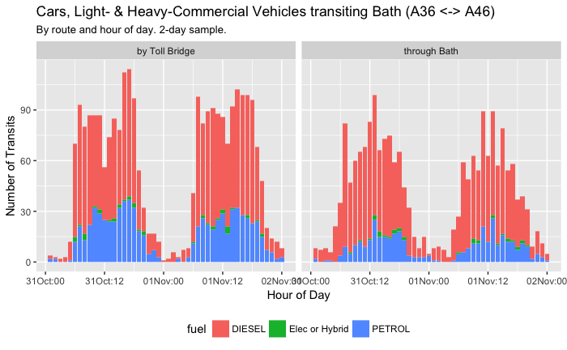

In our two-day sample, we have 4,703 vehicles in the Sankey chart, but only 4,589 in this bar chart. The remainder are odd/unclassified vehicles, see ealrier discussion.

## Age - Is of vehicle type, not vehicle

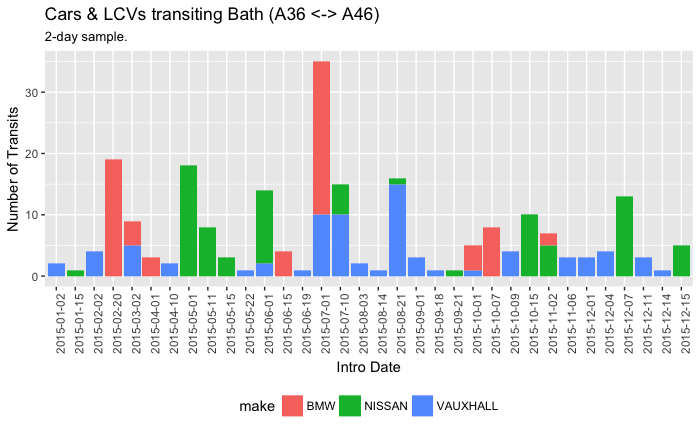

So we need to set age to one side, it appears we don’t have any data to allow testing the retirement rates that have been applied.